[figure not shown]

```python
#!pip install bqplot
#!pip install ipywidgets
#!pip install ipympl
#!jupyter labextension install @jupyter-widgets/jupyterlab-manager
#!jupyter nbextension install --user --py widgetsnbextension
#!jupyter nbextension enable --user --py widgetsnbextension
#!pip install plotly
#!pip install cufflinks


import operator
import pandas as pd
import numpy as np
import matplotlib.pyplot as plt
import seaborn as sns
%matplotlib inline
import warnings
warnings.filterwarnings("ignore")
import ipywidgets as widgets
import plotly.express as px
import plotly.graph_objects as go
import bqplot
from bqplot import Pie
from collections import Counter
from bqplot import DateScale, LinearScale, Lines, Axis, Figure
from bqplot import Tooltip
import cufflinks as cf
from matplotlib.patches import ConnectionPatch
from matplotlib.gridspec import GridSpec
import matplotlib.pyplot as plt

from IPython.core.display import display, HTML

def display_side_by_side(dfs:list, captions:list):
    """Display tables side by side to save vertical space
    Input:
        dfs: list of pandas.DataFrame
        captions: list of table captions
    """
    output = ""
    combined = dict(zip(captions, dfs))
    for caption, df in combined.items():
        output += df.style.set_table_attributes("style='display:inline'").set_caption(caption)._repr_html_()
        output += "\xa0\xa0\xa0"
    display(HTML(output))


from __future__ import print_function
from ipywidgets import interact, interactive, fixed, interact_manual
pd.set_option('display.max_columns', 50)
%matplotlib widget
```

# A) Dataset 1

## Parsing the table for Virat Kohli's dismissal stats

```python
import requests
import pandas as pd
from bs4 import BeautifulSoup

#dismissal stats for T20Is(2010-2020)
url_T20 = "https://stats.espncricinfo.com/ci/engine/player/253802.html?class=3;template=results;type=batting;view=dismissal_summary"
#dismissal stats for ODI
url_ODI = "https://stats.espncricinfo.com/ci/engine/player/253802.html?class=2;template=results;type=batting;view=dismissal_summary"
#dismissal stats for Test
url_test = "https://stats.espncricinfo.com/ci/engine/player/253802.html?class=1;template=results;type=batting;view=dismissal_summary"

def htmlData_parser(url):
    column_=[]
    response = requests.get(url)
    cric_data = BeautifulSoup(response.content, 'html.parser')
    container = cric_data.find("caption", text="Dismissal summary").find_parent("table")
    attr = container.find_all("tbody")
    for i in range(len(attr)):
        table_col = attr[i].find_all("td")
        for j in range(len(table_col)):
            column_.append(table_col[j].text)
    return column_

# Collect a required data
def required_data(column):
    dismissal_list = [column[0:15], column[15:30], column[30:45], column[46:61], column[61:76], column[76:91], column[92:107],
                 column[107:122], column[122:137],column[137:152], column[152:167], column[168:183],
                 column[183:198],column[198:213],column[213:228], column[228:243], column[243:258],
                 column[259:274], column[274:289], column[289:304], column[304:319], column[319:334],
                 column[334:349], column[349:364], column[364:379],column[380:395], column[395:410],
                column[410:425], column[425:440], column[440:455]]
    return dismissal_list

def required_data_ODI(column):
    dismissal_list1 = [column[0:15], column[15:30], column[30:45], column[46:61], column[61:76], column[76:91], column[92:107],
                 column[107:122], column[122:137],column[137:152], column[152:167], column[168:183],
                 column[183:198],column[198:213],column[213:228], column[228:243], column[243:258],
                 column[258:273], column[274:289], column[289:304],column[304:319], column[319:334],
                 column[334:349], column[349:364], column[364:379], column[379:394], column[394:409],
                 column[409:424], column[425:440], column[440:455], column[455:470], column[470:485], column[485:500],
                 column[500:515]]
    return dismissal_list1

def required_data_Test(column):
    dismissal_list2 = [column[0:15], column[15:30], column[30:45], column[46:61], column[61:76], column[76:91], column[92:107],
                 column[107:122], column[122:137],column[137:152], column[152:167], column[168:183],
                 column[183:198],column[198:213],column[213:228], column[228:243],
                       column[259:274], column[274:289], column[289:304],column[304:319], column[319:334],
                 column[334:349], column[349:364], column[364:379], column[379:394], column[394:409],
                 column[409:424], column[425:440], column[440:455], column[455:470], column[470:485], column[485:500],
                 column[500:515]
                 ]
    return dismissal_list2
```

## Creating a data frame from parsed data

## Data for T20Is(2010 - 2020)

```python
data_T20 = htmlData_parser(url_T20)
dismissal_list_T20 = required_data(data_T20)

dismissal_summary_T20 = pd.DataFrame(columns=['dismissal', 'span', 'Dis', 'bwd', 'c_fie', 'c_wk', 'st', 'lbw', 'hw', 'ro','oth','no','ave','0s','remove'], data=dismissal_list_T20)
dismissal_summary_T20.drop('remove', axis=1, inplace=True)
dismissal_summary_T20["batsman"] = "Virat Kohli"
#dismissal_summary_T20.to_csv("VKohli_T20.csv")
dismissal_summary_T20["match_type"] = "T20"
```

## Data for ODI(2008 - 2019/20)

```python
data_ODI = htmlData_parser(url_ODI)
dismissal_list_ODI = required_data_ODI(data_ODI)

dismissal_summary_ODI = pd.DataFrame(columns=['dismissal', 'span', 'Dis', 'bwd', 'c_fie', 'c_wk', 'st', 'lbw', 'hw', 'ro','oth','no','ave','0s','remove'], data=dismissal_list_ODI)
dismissal_summary_ODI.drop('remove', axis=1, inplace=True)
dismissal_summary_ODI["batsman"] = "Virat Kohli"
#dismissal_summary_ODI.to_csv("VKohli_ODI.csv")
dismissal_summary_ODI["match_type"] = "ODI"
```

## Data for Test(2011 - 2019/20)

```python
data_Test = htmlData_parser(url_test)
dismissal_list_Test = required_data_Test(data_Test)

dismissal_summary_Test = pd.DataFrame(columns=['dismissal', 'span', 'Dis', 'bwd', 'c_fie', 'c_wk', 'st', 'lbw', 'hw', 'ro','oth','no','ave','0s','remove'], data=dismissal_list_Test)
dismissal_summary_Test.drop('remove', axis=1, inplace=True)
dismissal_summary_Test["batsman"] = "Virat Kohli"
#dismissal_summary_Test.to_csv("VKohli_Test.csv")
dismissal_summary_Test["match_type"] = "Test"
```

```python
display_side_by_side([dismissal_summary_T20, dismissal_summary_Test, dismissal_summary_ODI],
                     ["1) Dismissal Summary of V Kohli in T20", "2) Dismissal Summary of V Kohli in Test",
                     "3) Dismissal Summary of V Kohli in ODI"])
```

1) Dismissal Summary of V Kohli in T20

|  | dismissal | span | Dis | bwd | c_fie | c_wk | st | lbw | hw | ro | oth | no | ave | 0s | batsman | match_type |
| --- | --- | --- | --- | --- | --- | --- | --- | --- | --- | --- | --- | --- | --- | --- | --- | --- |
| 0 | right-arm bowler | 2011-2020 | 40 | 5 | 26 | 7 | 0 | 2 | 0 | 0 | 0 | 0 | 27.12 | 1 | Virat Kohli | T20 |
| 1 | left-arm bowler | 2012-2019 | 10 | 1 | 6 | 2 | 0 | 1 | 0 | 0 | 0 | 0 | 36.80 | 1 | Virat Kohli | T20 |
| 2 | unknown arm | 2012-2020 | 5 | 0 | 0 | 0 | 0 | 0 | 0 | 5 | 0 | 0 | 26.60 | 0 | Virat Kohli | T20 |
| 3 | pace bowler | 2011-2020 | 37 | 3 | 25 | 7 | 0 | 2 | 0 | 0 | 0 | 0 | 29.24 | 2 | Virat Kohli | T20 |
| 4 | spin bowler | 2011-2019 | 13 | 3 | 7 | 2 | 0 | 1 | 0 | 0 | 0 | 0 | 28.53 | 0 | Virat Kohli | T20 |
| 5 | mixture/unknown | 2012-2020 | 5 | 0 | 0 | 0 | 0 | 0 | 0 | 5 | 0 | 0 | 26.60 | 0 | Virat Kohli | T20 |
| 6 | right-arm pace | 2011-2020 | 30 | 2 | 20 | 6 | 0 | 2 | 0 | 0 | 0 | 0 | 27.56 | 1 | Virat Kohli | T20 |
| 7 | right-arm spin | 2011-2019 | 10 | 3 | 6 | 1 | 0 | 0 | 0 | 0 | 0 | 0 | 25.80 | 0 | Virat Kohli | T20 |
| 8 | left-arm pace | 2012-2019 | 7 | 1 | 5 | 1 | 0 | 0 | 0 | 0 | 0 | 0 | 36.42 | 1 | Virat Kohli | T20 |
| 9 | left-arm spin | 2012-2018 | 3 | 0 | 1 | 1 | 0 | 1 | 0 | 0 | 0 | 0 | 37.66 | 0 | Virat Kohli | T20 |
| 10 | mixture/unknown | 2012-2020 | 5 | 0 | 0 | 0 | 0 | 0 | 0 | 5 | 0 | 0 | 26.60 | 0 | Virat Kohli | T20 |
| 11 | 1st position | 2011-2017 | 5 | 1 | 3 | 0 | 0 | 0 | 0 | 1 | 0 | 0 | 23.80 | 0 | Virat Kohli | T20 |
| 12 | 2nd position | 2012-2018 | 2 | 0 | 2 | 0 | 0 | 0 | 0 | 0 | 0 | 0 | 39.50 | 0 | Virat Kohli | T20 |
| 13 | 3rd position | 2011-2020 | 36 | 5 | 20 | 6 | 0 | 2 | 0 | 3 | 0 | 16 | 58.94 | 1 | Virat Kohli | T20 |
| 14 | 4th position | 2011-2020 | 10 | 0 | 6 | 3 | 0 | 1 | 0 | 0 | 0 | 4 | 42.20 | 0 | Virat Kohli | T20 |
| 15 | 5th position | 2010-2010 | 0 | 0 | 0 | 0 | 0 | 0 | 0 | 0 | 0 | 1 | - | 0 | Virat Kohli | T20 |
| 16 | 6th position | 2018-2020 | 2 | 0 | 1 | 0 | 0 | 0 | 0 | 1 | 0 | 0 | 13.00 | 1 | Virat Kohli | T20 |
| 17 | 0 runs | 2017-2018 | 2 | 0 | 2 | 0 | 0 | 0 | 0 | 0 | 0 | 0 | 0.00 | 2 | Virat Kohli | T20 |
| 18 | 1-9 runs | 2011-2019 | 10 | 0 | 4 | 4 | 0 | 0 | 0 | 2 | 0 | 0 | 4.80 | 0 | Virat Kohli | T20 |
| 19 | 10-19 runs | 2011-2020 | 9 | 0 | 7 | 2 | 0 | 0 | 0 | 0 | 0 | 0 | 14.77 | 0 | Virat Kohli | T20 |
| 20 | 20-29 runs | 2010-2020 | 14 | 4 | 6 | 1 | 0 | 1 | 0 | 2 | 0 | 4 | 31.78 | 0 | Virat Kohli | T20 |
| 21 | 30-39 runs | 2012-2020 | 4 | 0 | 2 | 1 | 0 | 1 | 0 | 0 | 0 | 2 | 53.00 | 0 | Virat Kohli | T20 |
| 22 | 40-49 runs | 2012-2020 | 6 | 0 | 5 | 0 | 0 | 1 | 0 | 0 | 0 | 1 | 51.33 | 0 | Virat Kohli | T20 |
| 23 | 50-89 runs | 2012-2019 | 10 | 2 | 6 | 1 | 0 | 0 | 0 | 1 | 0 | 12 | 146.40 | 0 | Virat Kohli | T20 |
| 24 | 90-99 runs | 2016-2019 | 0 | 0 | 0 | 0 | 0 | 0 | 0 | 0 | 0 | 2 | - | 0 | Virat Kohli | T20 |
| 25 | caught | 2011-2020 | 41 | 0 | 32 | 9 | 0 | 0 | 0 | 0 | 0 | 0 | 27.68 | 2 | Virat Kohli | T20 |
| 26 | bowled | 2011-2019 | 6 | 6 | 0 | 0 | 0 | 0 | 0 | 0 | 0 | 0 | 34.16 | 0 | Virat Kohli | T20 |
| 27 | leg before wicket | 2012-2018 | 3 | 0 | 0 | 0 | 0 | 3 | 0 | 0 | 0 | 0 | 37.66 | 0 | Virat Kohli | T20 |
| 28 | run out | 2012-2020 | 5 | 0 | 0 | 0 | 0 | 0 | 0 | 5 | 0 | 0 | 26.60 | 0 | Virat Kohli | T20 |
| 29 | not out | 2010-2020 | 0 | 0 | 0 | 0 | 0 | 0 | 0 | 0 | 0 | 21 | - | 0 | Virat Kohli | T20 |

2) Dismissal Summary of V Kohli in Test

|  | dismissal | span | Dis | bwd | c_fie | c_wk | st | lbw | hw | ro | oth | no | ave | 0s | batsman | match_type |
| --- | --- | --- | --- | --- | --- | --- | --- | --- | --- | --- | --- | --- | --- | --- | --- | --- |
| 0 | right-arm bowler | 2011-2020 | 112 | 5 | 55 | 24 | 0 | 27 | 1 | 0 | 0 | 0 | 45.69 | 9 | Virat Kohli | Test |
| 1 | left-arm bowler | 2012-2020 | 22 | 2 | 14 | 3 | 0 | 3 | 0 | 0 | 0 | 0 | 59.81 | 1 | Virat Kohli | Test |
| 2 | unknown arm | 2012-2012 | 1 | 0 | 0 | 0 | 0 | 0 | 0 | 1 | 0 | 0 | 22.00 | 0 | Virat Kohli | Test |
| 3 | pace bowler | 2011-2020 | 90 | 4 | 42 | 24 | 0 | 20 | 0 | 0 | 0 | 0 | 40.14 | 10 | Virat Kohli | Test |
| 4 | spin bowler | 2011-2019 | 44 | 3 | 27 | 3 | 0 | 10 | 1 | 0 | 0 | 0 | 64.11 | 0 | Virat Kohli | Test |
| 5 | mixture/unknown | 2012-2012 | 1 | 0 | 0 | 0 | 0 | 0 | 0 | 1 | 0 | 0 | 22.00 | 0 | Virat Kohli | Test |
| 6 | right-arm pace | 2011-2020 | 77 | 3 | 34 | 21 | 0 | 19 | 0 | 0 | 0 | 0 | 38.53 | 9 | Virat Kohli | Test |
| 7 | right-arm spin | 2011-2019 | 35 | 2 | 21 | 3 | 0 | 8 | 1 | 0 | 0 | 0 | 61.45 | 0 | Virat Kohli | Test |
| 8 | left-arm pace | 2014-2020 | 13 | 1 | 8 | 3 | 0 | 1 | 0 | 0 | 0 | 0 | 49.69 | 1 | Virat Kohli | Test |
| 9 | left-arm spin | 2012-2019 | 9 | 1 | 6 | 0 | 0 | 2 | 0 | 0 | 0 | 0 | 74.44 | 0 | Virat Kohli | Test |
| 10 | mixture/unknown | 2012-2012 | 1 | 0 | 0 | 0 | 0 | 0 | 0 | 1 | 0 | 0 | 22.00 | 0 | Virat Kohli | Test |
| 11 | 3rd position | 2012-2016 | 5 | 0 | 2 | 0 | 0 | 3 | 0 | 0 | 0 | 1 | 19.40 | 0 | Virat Kohli | Test |
| 12 | 4th position | 2013-2020 | 97 | 5 | 50 | 20 | 0 | 21 | 1 | 0 | 0 | 6 | 59.07 | 8 | Virat Kohli | Test |
| 13 | 5th position | 2011-2019 | 23 | 2 | 14 | 4 | 0 | 3 | 0 | 0 | 0 | 3 | 43.39 | 1 | Virat Kohli | Test |
| 14 | 6th position | 2011-2012 | 9 | 0 | 3 | 2 | 0 | 3 | 0 | 1 | 0 | 0 | 44.88 | 1 | Virat Kohli | Test |
| 15 | 7th position | 2011-2011 | 1 | 0 | 0 | 1 | 0 | 0 | 0 | 0 | 0 | 0 | 11.00 | 0 | Virat Kohli | Test |
| 16 | 1-9 runs | 2011-2020 | 26 | 1 | 15 | 3 | 0 | 7 | 0 | 0 | 0 | 1 | 4.92 | 0 | Virat Kohli | Test |
| 17 | 10-19 runs | 2011-2020 | 22 | 3 | 7 | 6 | 0 | 6 | 0 | 0 | 0 | 1 | 15.81 | 0 | Virat Kohli | Test |
| 18 | 20-29 runs | 2011-2019 | 14 | 0 | 5 | 7 | 0 | 1 | 0 | 1 | 0 | 0 | 23.64 | 0 | Virat Kohli | Test |
| 19 | 30-39 runs | 2011-2019 | 7 | 0 | 6 | 1 | 0 | 0 | 0 | 0 | 0 | 1 | 39.71 | 0 | Virat Kohli | Test |
| 20 | 40-49 runs | 2012-2018 | 13 | 1 | 6 | 2 | 0 | 3 | 1 | 0 | 0 | 1 | 47.84 | 0 | Virat Kohli | Test |
| 21 | 50-89 runs | 2011-2019 | 18 | 0 | 12 | 4 | 0 | 2 | 0 | 0 | 0 | 2 | 70.83 | 0 | Virat Kohli | Test |
| 22 | 90-99 runs | 2013-2018 | 2 | 0 | 1 | 1 | 0 | 0 | 0 | 0 | 0 | 0 | 96.50 | 0 | Virat Kohli | Test |
| 23 | 100-149 runs | 2012-2019 | 14 | 0 | 9 | 0 | 0 | 5 | 0 | 0 | 0 | 3 | 144.00 | 0 | Virat Kohli | Test |
| 24 | 150-199 runs | 2014-2018 | 3 | 0 | 2 | 1 | 0 | 0 | 0 | 0 | 0 | 0 | 163.00 | 0 | Virat Kohli | Test |
| 25 | 200-249 runs | 2016-2017 | 6 | 1 | 2 | 0 | 0 | 3 | 0 | 0 | 0 | 0 | 217.66 | 0 | Virat Kohli | Test |
| 26 | 250-299 runs | 2019-2019 | 0 | 0 | 0 | 0 | 0 | 0 | 0 | 0 | 0 | 1 | - | 0 | Virat Kohli | Test |
| 27 | caught | 2011-2020 | 96 | 0 | 69 | 27 | 0 | 0 | 0 | 0 | 0 | 0 | 46.93 | 6 | Virat Kohli | Test |
| 28 | bowled | 2012-2018 | 7 | 7 | 0 | 0 | 0 | 0 | 0 | 0 | 0 | 0 | 41.14 | 1 | Virat Kohli | Test |
| 29 | leg before wicket | 2011-2020 | 30 | 0 | 0 | 0 | 0 | 30 | 0 | 0 | 0 | 0 | 53.33 | 3 | Virat Kohli | Test |
| 30 | run out | 2012-2012 | 1 | 0 | 0 | 0 | 0 | 0 | 0 | 1 | 0 | 0 | 22.00 | 0 | Virat Kohli | Test |
| 31 | hit wicket | 2016-2016 | 1 | 0 | 0 | 0 | 0 | 0 | 1 | 0 | 0 | 0 | 40.00 | 0 | Virat Kohli | Test |
| 32 | not out | 2012-2019 | 0 | 0 | 0 | 0 | 0 | 0 | 0 | 0 | 0 | 10 | - | 0 | Virat Kohli | Test |

3) Dismissal Summary of V Kohli in ODI

|  | dismissal | span | Dis | bwd | c_fie | c_wk | st | lbw | hw | ro | oth | no | ave | 0s | batsman | match_type |
| --- | --- | --- | --- | --- | --- | --- | --- | --- | --- | --- | --- | --- | --- | --- | --- | --- |
| 0 | right-arm bowler | 2008-2020 | 147 | 20 | 74 | 37 | 3 | 12 | 1 | 0 | 0 | 0 | 46.75 | 8 | Virat Kohli | ODI |
| 1 | left-arm bowler | 2008-2019 | 41 | 7 | 23 | 8 | 1 | 2 | 0 | 0 | 0 | 0 | 31.60 | 3 | Virat Kohli | ODI |
| 2 | unknown arm | 2008-2018 | 12 | 0 | 0 | 0 | 0 | 0 | 0 | 12 | 0 | 0 | 46.00 | 2 | Virat Kohli | ODI |
| 3 | pace bowler | 2008-2020 | 131 | 15 | 69 | 40 | 0 | 7 | 0 | 0 | 0 | 0 | 41.61 | 11 | Virat Kohli | ODI |
| 4 | spin bowler | 2009-2020 | 57 | 12 | 28 | 5 | 4 | 7 | 1 | 0 | 0 | 0 | 47.68 | 0 | Virat Kohli | ODI |
| 5 | mixture/unknown | 2008-2018 | 12 | 0 | 0 | 0 | 0 | 0 | 0 | 12 | 0 | 0 | 46.00 | 2 | Virat Kohli | ODI |
| 6 | right-arm pace | 2008-2020 | 103 | 11 | 53 | 33 | 0 | 6 | 0 | 0 | 0 | 0 | 44.45 | 8 | Virat Kohli | ODI |
| 7 | right-arm spin | 2009-2020 | 44 | 9 | 21 | 4 | 3 | 6 | 1 | 0 | 0 | 0 | 52.13 | 0 | Virat Kohli | ODI |
| 8 | left-arm pace | 2008-2019 | 28 | 4 | 16 | 7 | 0 | 1 | 0 | 0 | 0 | 0 | 31.14 | 3 | Virat Kohli | ODI |
| 9 | left-arm spin | 2009-2017 | 13 | 3 | 7 | 1 | 1 | 1 | 0 | 0 | 0 | 0 | 32.61 | 0 | Virat Kohli | ODI |
| 10 | mixture/unknown | 2008-2018 | 12 | 0 | 0 | 0 | 0 | 0 | 0 | 12 | 0 | 0 | 46.00 | 2 | Virat Kohli | ODI |
| 11 | 1st position | 2008-2008 | 3 | 1 | 0 | 0 | 0 | 1 | 0 | 1 | 0 | 0 | 36.66 | 0 | Virat Kohli | ODI |
| 12 | 2nd position | 2008-2014 | 3 | 0 | 2 | 0 | 0 | 1 | 0 | 0 | 0 | 0 | 17.00 | 0 | Virat Kohli | ODI |
| 13 | 3rd position | 2009-2020 | 155 | 20 | 74 | 40 | 4 | 9 | 0 | 8 | 0 | 30 | 62.90 | 13 | Virat Kohli | ODI |
| 14 | 4th position | 2009-2020 | 32 | 2 | 18 | 5 | 0 | 3 | 1 | 3 | 0 | 7 | 55.21 | 0 | Virat Kohli | ODI |
| 15 | 5th position | 2010-2017 | 4 | 2 | 2 | 0 | 0 | 0 | 0 | 0 | 0 | 0 | 31.75 | 0 | Virat Kohli | ODI |
| 16 | 6th position | 2011-2011 | 0 | 0 | 0 | 0 | 0 | 0 | 0 | 0 | 0 | 1 | - | 0 | Virat Kohli | ODI |
| 17 | 7th position | 2009-2011 | 3 | 2 | 1 | 0 | 0 | 0 | 0 | 0 | 0 | 1 | 12.66 | 0 | Virat Kohli | ODI |
| 18 | 0 runs | 2010-2019 | 13 | 2 | 5 | 3 | 0 | 1 | 0 | 2 | 0 | 0 | 0.00 | 13 | Virat Kohli | ODI |
| 19 | 1-9 runs | 2009-2020 | 40 | 4 | 15 | 20 | 0 | 1 | 0 | 0 | 0 | 3 | 4.95 | 0 | Virat Kohli | ODI |
| 20 | 10-19 runs | 2008-2020 | 24 | 3 | 9 | 8 | 1 | 2 | 0 | 1 | 0 | 0 | 14.12 | 0 | Virat Kohli | ODI |
| 21 | 20-29 runs | 2008-2019 | 20 | 4 | 6 | 4 | 1 | 3 | 0 | 2 | 0 | 2 | 26.35 | 0 | Virat Kohli | ODI |
| 22 | 30-39 runs | 2008-2019 | 19 | 1 | 13 | 0 | 0 | 3 | 0 | 2 | 0 | 4 | 41.26 | 0 | Virat Kohli | ODI |
| 23 | 40-49 runs | 2013-2019 | 11 | 1 | 5 | 3 | 0 | 2 | 0 | 0 | 0 | 2 | 53.09 | 0 | Virat Kohli | ODI |
| 24 | 50-89 runs | 2008-2020 | 40 | 8 | 22 | 4 | 1 | 2 | 0 | 3 | 0 | 12 | 91.92 | 0 | Virat Kohli | ODI |
| 25 | 90-99 runs | 2010-2017 | 5 | 1 | 3 | 0 | 0 | 0 | 0 | 1 | 0 | 1 | 112.60 | 0 | Virat Kohli | ODI |
| 26 | 100-149 runs | 2009-2019 | 27 | 3 | 18 | 3 | 1 | 0 | 1 | 1 | 0 | 12 | 168.18 | 0 | Virat Kohli | ODI |
| 27 | 150-199 runs | 2012-2018 | 1 | 0 | 1 | 0 | 0 | 0 | 0 | 0 | 0 | 3 | 654.00 | 0 | Virat Kohli | ODI |
| 28 | caught | 2008-2020 | 142 | 0 | 97 | 45 | 0 | 0 | 0 | 0 | 0 | 0 | 43.56 | 8 | Virat Kohli | ODI |
| 29 | bowled | 2008-2020 | 27 | 27 | 0 | 0 | 0 | 0 | 0 | 0 | 0 | 0 | 45.66 | 2 | Virat Kohli | ODI |
| 30 | leg before wicket | 2008-2019 | 14 | 0 | 0 | 0 | 0 | 14 | 0 | 0 | 0 | 0 | 28.21 | 1 | Virat Kohli | ODI |
| 31 | run out | 2008-2018 | 12 | 0 | 0 | 0 | 0 | 0 | 0 | 12 | 0 | 0 | 46.00 | 2 | Virat Kohli | ODI |
| 32 | stumped | 2010-2018 | 4 | 0 | 0 | 0 | 4 | 0 | 0 | 0 | 0 | 0 | 62.00 | 0 | Virat Kohli | ODI |
| 33 | hit wicket | 2011-2011 | 1 | 0 | 0 | 0 | 0 | 0 | 1 | 0 | 0 | 0 | 107.00 | 0 | Virat Kohli | ODI |

## CSV file

```python
vkohli_dismissal_data = dismissal_summary_T20.append(dismissal_summary_Test,ignore_index = True).append(dismissal_summary_ODI, ignore_index = True)
vkohli_dismissal_data.to_csv("VKohli_dismissal_data.csv")
```

# B) Dataset 2

# List of Dismissals

```python
def htmlData_parser_dismissals(url):
    column_=[]
    response = requests.get(url)
    cric_data = BeautifulSoup(response.content, 'html.parser')
    container = cric_data.find("caption", text="List of dismissals").find_parent("table")
    attr = container.find_all("tbody")
    for i in range(len(attr)):
        table_col = attr[i].find_all("td")
        for j in range(len(table_col)):
            column_.append(table_col[j].text)
    return column_

def split_list (x, list_):
   return [list_[i:i+x] for i in range(0, len(list_), x)]
```

```python
def list_of_dismissal(url_ra_pace, url_ra_spin, url_la_pace, url_la_spin, match_type):

    ## Type of bowler : right arm pace

    right_arm_pace = htmlData_parser_dismissals(url_ra_pace)
    right_arm_pace_list = split_list(10, right_arm_pace)
    dismissal_summary_ra = pd.DataFrame(columns=['how out', 'fielder', 'bowler', 'runs', 'Inns', 'remove', 'opposition','Ground', 'Start Date', 'Test_no'], data=right_arm_pace_list)
    dismissal_summary_ra.drop('remove', axis=1, inplace=True)
    dismissal_summary_ra["batsman"] = "Virat Kohli"
    dismissal_summary_ra["bowler_type"] = "right_arm_pace"
    dismissal_summary_ra["match_type"]  = match_type

    ## Type of bowler : right-arm spin

    right_arm_spin = htmlData_parser_dismissals(url_ra_spin)
    right_arm_spin_list = split_list(10, right_arm_spin)
    dismissal_summary_rs = pd.DataFrame(columns=['how out', 'fielder', 'bowler', 'runs', 'Inns', 'remove', 'opposition','Ground', 'Start Date', 'Test_no'], data=right_arm_spin_list)
    dismissal_summary_rs.drop('remove', axis=1, inplace=True)
    dismissal_summary_rs["batsman"] = "Virat Kohli"
    dismissal_summary_rs["bowler_type"] = "right_arm_spin"
    dismissal_summary_rs["match_type"]  = match_type

    ## Type of bowler : left arm pace

    left_arm_pace = htmlData_parser_dismissals(url_la_pace)
    left_arm_pace_list = split_list(10, left_arm_pace)
    dismissal_summary_la = pd.DataFrame(columns=['how out', 'fielder', 'bowler', 'runs', 'Inns', 'remove', 'opposition','Ground', 'Start Date', 'Test_no'], data=left_arm_pace_list)
    dismissal_summary_la.drop('remove', axis=1, inplace=True)
    dismissal_summary_la["batsman"] = "Virat Kohli"
    dismissal_summary_la["bowler_type"] = "left_arm_pace"
    dismissal_summary_la["match_type"]  = match_type

    ## Type of bowler : Left Arm Spin

    left_arm_spin = htmlData_parser_dismissals(url_la_spin)
    left_arm_spin_list = split_list(10, left_arm_spin)
    dismissal_summary_ls = pd.DataFrame(columns=['how out', 'fielder', 'bowler', 'runs', 'Inns', 'remove', 'opposition','Ground', 'Start Date', 'Test_no'], data=left_arm_spin_list)
    dismissal_summary_ls.drop('remove', axis=1, inplace=True)
    dismissal_summary_ls["batsman"] = "Virat Kohli"
    dismissal_summary_ls["bowler_type"] = "left_arm_spin"
    dismissal_summary_ls["match_type"]  = match_type
    list_of_dismissal_Test = dismissal_summary_ra.append(dismissal_summary_rs, ignore_index = True).append(dismissal_summary_la, ignore_index = True).append(dismissal_summary_ls, ignore_index = True)
    return list_of_dismissal_Test
```

# 1. Test(2011 - 2019/20)

```python
def get_urls_data(url):
    href = []
    response1 = requests.get(url)
    cric_data1 = BeautifulSoup(response1.content, 'html.parser')
    container1 = cric_data1.find("caption", text="List of dismissals").find_parent("table")
    attr1 = container1.find_all("tbody")
    for i in range(len(attr1)):
        table_col1 = attr[i].find_all("a")
        for j in range(len(table_col1)):
            if "/match/" in table_col1[j].get("href"):
                link = "https://www.espncricinfo.com" + table_col1[j].get("href")
                #print(link)
                href.append(link)
    return href


def get_comments(href):
    comment =[]
    for i in href:
        t =i
        response1 = requests.get(t)
        cric_data1 = BeautifulSoup(response1.content, 'html.parser')
        data_=[]
        for i1 in cric_data1:
            data_.append(i1)

        x =("%s\n" % data_)
        for i2 in x.split('"commentary":'):
            if "Virat" in i2:
                #print(i)
                c2 = t + i2.split('"')[1]
                comment.append(c2)
    return comment
```

```python
url_ra_pace = "https://stats.espncricinfo.com/ci/engine/player/253802.html?bowling_hand_pacespin=11;class=1;template=results;type=batting;view=dismissal_list"
url_ra_spin = "https://stats.espncricinfo.com/ci/engine/player/253802.html?bowling_hand_pacespin=12;class=1;template=results;type=batting;view=dismissal_list"
url_la_pace = "https://stats.espncricinfo.com/ci/engine/player/253802.html?bowling_hand_pacespin=21;class=1;template=results;type=batting;view=dismissal_list"
url_la_spin ="https://stats.espncricinfo.com/ci/engine/player/253802.html?bowling_hand_pacespin=22;class=1;template=results;type=batting;view=dismissal_list"


list_of_dismissal_Test_vk = list_of_dismissal(url_ra_pace, url_ra_spin, url_la_pace, url_la_spin, "Test")
```

# 2. ODI

```python
url_ra_pace1 = "https://stats.espncricinfo.com/ci/engine/player/253802.html?bowling_hand_pacespin=11;class=2;template=results;type=batting;view=dismissal_list"
url_ra_spin1 = "https://stats.espncricinfo.com/ci/engine/player/253802.html?bowling_hand_pacespin=12;class=2;template=results;type=batting;view=dismissal_list"
url_la_pace1 = "https://stats.espncricinfo.com/ci/engine/player/253802.html?bowling_hand_pacespin=21;class=2;template=results;type=batting;view=dismissal_list"
url_la_spin1 ="https://stats.espncricinfo.com/ci/engine/player/253802.html?bowling_hand_pacespin=22;class=2;template=results;type=batting;view=dismissal_list"

list_of_dismissal_ODI_vk = list_of_dismissal(url_ra_pace1, url_ra_spin1, url_la_pace1, url_la_spin1, "ODI")
```

# 3. T20

```python
url_ra_pace2 = "https://stats.espncricinfo.com/ci/engine/player/253802.html?bowling_hand_pacespin=11;class=3;template=results;type=batting;view=dismissal_list"
url_ra_spin2 = "https://stats.espncricinfo.com/ci/engine/player/253802.html?bowling_hand_pacespin=12;class=3;template=results;type=batting;view=dismissal_list"
url_la_pace2 = "https://stats.espncricinfo.com/ci/engine/player/253802.html?bowling_hand_pacespin=21;class=3;template=results;type=batting;view=dismissal_list"
url_la_spin2 ="https://stats.espncricinfo.com/ci/engine/player/253802.html?bowling_hand_pacespin=22;class=3;template=results;type=batting;view=dismissal_list"

list_of_dismissal_T20_vk = list_of_dismissal(url_ra_pace2, url_ra_spin2, url_la_pace2, url_la_spin2, "T20")
display_side_by_side([list_of_dismissal_Test_vk, list_of_dismissal_T20_vk, list_of_dismissal_ODI_vk],
                    ["1) List of diamissals in Test", "2) List of diamissals in T20",
                    "3) List of diamissals in ODI"])
```

1) List of diamissals in Test

|  | how out | fielder | bowler | runs | Inns | opposition | Ground | Start Date | Test_no | batsman | bowler_type | match_type |
| --- | --- | --- | --- | --- | --- | --- | --- | --- | --- | --- | --- | --- |
| 0 | caught | CS Baugh | FH Edwards | 4 | 1 | v West Indies | Kingston | 20 Jun 2011 | Test # 1997 | Virat Kohli | right_arm_pace | Test |
| 1 | caught | CS Baugh | FH Edwards | 15 | 3 | v West Indies | Kingston | 20 Jun 2011 | Test # 1997 | Virat Kohli | right_arm_pace | Test |
| 2 | caught | DJG Sammy | R Rampaul | 0 | 1 | v West Indies | Bridgetown | 28 Jun 2011 | Test # 1998 | Virat Kohli | right_arm_pace | Test |
| 3 | caught | DJG Sammy | FH Edwards | 27 | 3 | v West Indies | Bridgetown | 28 Jun 2011 | Test # 1998 | Virat Kohli | right_arm_pace | Test |
| 4 | caught | CS Baugh | DJG Sammy | 30 | 2 | v West Indies | Roseau | 6 Jul 2011 | Test # 1999 | Virat Kohli | right_arm_pace | Test |
| 5 | caught | BJ Haddin | BW Hilfenhaus | 11 | 2 | v Australia | Melbourne | 26 Dec 2011 | Test # 2025 | Virat Kohli | right_arm_pace | Test |
| 6 | lbw |  | BW Hilfenhaus | 0 | 4 | v Australia | Melbourne | 26 Dec 2011 | Test # 2025 | Virat Kohli | right_arm_pace | Test |
| 7 | caught | BJ Haddin | PM Siddle | 23 | 1 | v Australia | Sydney | 3 Jan 2012 | Test # 2027 | Virat Kohli | right_arm_pace | Test |
| 8 | lbw |  | JL Pattinson | 9 | 3 | v Australia | Sydney | 3 Jan 2012 | Test # 2027 | Virat Kohli | right_arm_pace | Test |
| 9 | caught | DA Warner | PM Siddle | 44 | 1 | v Australia | Perth | 13 Jan 2012 | Test # 2029 | Virat Kohli | right_arm_pace | Test |
| 10 | caught | BJ Haddin | PM Siddle | 75 | 3 | v Australia | Perth | 13 Jan 2012 | Test # 2029 | Virat Kohli | right_arm_pace | Test |
| 11 | lbw |  | BW Hilfenhaus | 116 | 2 | v Australia | Adelaide | 24 Jan 2012 | Test # 2031 | Virat Kohli | right_arm_pace | Test |
| 12 | caught | MJ Guptill | CS Martin | 58 | 1 | v New Zealand | Hyderabad (Deccan) | 23 Aug 2012 | Test # 2054 | Virat Kohli | right_arm_pace | Test |
| 13 | lbw |  | TG Southee | 103 | 2 | v New Zealand | Bengaluru | 31 Aug 2012 | Test # 2055 | Virat Kohli | right_arm_pace | Test |
| 14 | caught | GP Swann | JM Anderson | 6 | 1 | v England | Kolkata | 5 Dec 2012 | Test # 2065 | Virat Kohli | right_arm_pace | Test |
| 15 | caught | MJ Prior | ST Finn | 20 | 3 | v England | Kolkata | 5 Dec 2012 | Test # 2065 | Virat Kohli | right_arm_pace | Test |
| 16 | caught | PJ Hughes | PM Siddle | 34 | 4 | v Australia | Mohali | 14 Mar 2013 | Test # 2081 | Virat Kohli | right_arm_pace | Test |
| 17 | caught | JP Duminy | JH Kallis | 119 | 1 | v South Africa | Johannesburg | 18 Dec 2013 | Test # 2108 | Virat Kohli | right_arm_pace | Test |
| 18 | caught | AB de Villiers | M Morkel | 46 | 1 | v South Africa | Durban | 26 Dec 2013 | Test # 2111 | Virat Kohli | right_arm_pace | Test |
| 19 | caught | AB de Villiers | DW Steyn | 11 | 3 | v South Africa | Durban | 26 Dec 2013 | Test # 2111 | Virat Kohli | right_arm_pace | Test |
| 20 | caught | PG Fulton | TG Southee | 4 | 2 | v New Zealand | Auckland | 6 Feb 2014 | Test # 2118 | Virat Kohli | right_arm_pace | Test |
| 21 | caught | IR Bell | SCJ Broad | 1 | 1 | v England | Nottingham | 9 Jul 2014 | Test # 2128 | Virat Kohli | right_arm_pace | Test |
| 22 | lbw |  | SCJ Broad | 8 | 3 | v England | Nottingham | 9 Jul 2014 | Test # 2128 | Virat Kohli | right_arm_pace | Test |
| 23 | caught | MJ Prior | JM Anderson | 25 | 1 | v England | Lord's | 17 Jul 2014 | Test # 2130 | Virat Kohli | right_arm_pace | Test |
| 24 | bowled |  | LE Plunkett | 0 | 3 | v England | Lord's | 17 Jul 2014 | Test # 2130 | Virat Kohli | right_arm_pace | Test |
| 25 | caught | AN Cook | JM Anderson | 39 | 2 | v England | Southampton | 27 Jul 2014 | Test # 2132 | Virat Kohli | right_arm_pace | Test |
| 26 | caught | AN Cook | JM Anderson | 0 | 1 | v England | Manchester | 7 Aug 2014 | Test # 2134 | Virat Kohli | right_arm_pace | Test |
| 27 | caught | IR Bell | JM Anderson | 7 | 3 | v England | Manchester | 7 Aug 2014 | Test # 2134 | Virat Kohli | right_arm_pace | Test |
| 28 | lbw |  | CJ Jordan | 6 | 1 | v England | The Oval | 15 Aug 2014 | Test # 2137 | Virat Kohli | right_arm_pace | Test |
| 29 | caught | AN Cook | CJ Jordan | 20 | 3 | v England | The Oval | 15 Aug 2014 | Test # 2137 | Virat Kohli | right_arm_pace | Test |

[output cut: 104 more lines]

2) List of diamissals in T20

|  | how out | fielder | bowler | runs | Inns | opposition | Ground | Start Date | Test_no | batsman | bowler_type | match_type |
| --- | --- | --- | --- | --- | --- | --- | --- | --- | --- | --- | --- | --- |
| 0 | caught | DP Hyatt | DJG Sammy | 14 | 1 | v West Indies | Port of Spain | 4 Jun 2011 | T20I # 200 | Virat Kohli | right_arm_pace | T20 |
| 1 | caught | C Kieswetter | SCJ Broad | 4 | 1 | v England | Manchester | 31 Aug 2011 | T20I # 204 | Virat Kohli | right_arm_pace | T20 |
| 2 | caught | AD Hales | TT Bresnan | 15 | 1 | v England | Kolkata | 29 Oct 2011 | T20I # 214 | Virat Kohli | right_arm_pace | T20 |
| 3 | caught | MS Wade | MR Marsh | 31 | 2 | v Australia | Melbourne | 3 Feb 2012 | T20I # 218 | Virat Kohli | right_arm_pace | T20 |
| 4 | caught | HDRL Thirimanne | RMS Eranga | 68 | 1 | v Sri Lanka | Pallekele | 7 Aug 2012 | T20I # 255 | Virat Kohli | right_arm_pace | T20 |
| 5 | caught | Mohammad Nabi | Dawlat Zadran | 50 | 1 | v Afghanistan | Colombo (RPS) | 19 Sep 2012 | T20I # 265 | Virat Kohli | right_arm_pace | T20 |
| 6 | caught | DT Christian | PJ Cummins | 15 | 1 | v Australia | Colombo (RPS) | 28 Sep 2012 | T20I # 278 | Virat Kohli | right_arm_pace | T20 |
| 7 | caught | AB de Villiers | JH Kallis | 2 | 1 | v South Africa | Colombo (RPS) | 2 Oct 2012 | T20I # 286 | Virat Kohli | right_arm_pace | T20 |
| 8 | bowled |  | SC Meaker | 21 | 2 | v England | Pune | 20 Dec 2012 | T20I # 292 | Virat Kohli | right_arm_pace | T20 |
| 9 | lbw |  | SC Meaker | 38 | 1 | v England | Mumbai | 22 Dec 2012 | T20I # 294 | Virat Kohli | right_arm_pace | T20 |
| 10 | caught | JP Faulkner | CJ McKay | 29 | 2 | v Australia | Rajkot | 10 Oct 2013 | T20I # 331 | Virat Kohli | right_arm_pace | T20 |
| 11 | bowled |  | AD Russell | 54 | 2 | v West Indies | Dhaka | 23 Mar 2014 | T20I # 382 | Virat Kohli | right_arm_pace | T20 |
| 12 | caught | AD Hales | ST Finn | 66 | 2 | v England | Birmingham | 7 Sep 2014 | T20I # 405 | Virat Kohli | right_arm_pace | T20 |
| 13 | caught | JP Duminy | KJ Abbott | 43 | 1 | v South Africa | Dharamsala | 2 Oct 2015 | T20I # 456 | Virat Kohli | right_arm_pace | T20 |
| 14 | caught | Mahmudullah | Mashrafe Mortaza | 7 | 1 | v Bangladesh | Dhaka | 24 Feb 2016 | T20I # 509 | Virat Kohli | right_arm_pace | T20 |
| 15 | lbw |  | Mohammad Sami | 49 | 2 | v Pakistan | Dhaka | 27 Feb 2016 | T20I # 512 | Virat Kohli | right_arm_pace | T20 |
| 16 | caught | ADS Fletcher | DJ Bravo | 16 | 2 | v West Indies | Lauderhill | 27 Aug 2016 | T20I # 562 | Virat Kohli | right_arm_pace | T20 |
| 17 | caught | LA Dawson | CJ Jordan | 21 | 1 | v England | Nagpur | 29 Jan 2017 | T20I # 593 | Virat Kohli | right_arm_pace | T20 |
| 18 | caught | SP Narine | KOK Williams | 39 | 1 | v West Indies | Kingston | 9 Jul 2017 | T20I # 617 | Virat Kohli | right_arm_pace | T20 |
| 19 | caught | H Klaasen | CJ Dala | 1 | 1 | v South Africa | Centurion | 21 Feb 2018 | T20I # 654 | Virat Kohli | right_arm_pace | T20 |
| 20 | caught | SR Thompson | PKD Chase | 0 | 1 | v Ireland | Dublin (Malahide) | 27 Jun 2018 | T20I # 678 | Virat Kohli | right_arm_pace | T20 |
| 21 | caught | GH Dockrell | PKD Chase | 9 | 1 | v Ireland | Dublin (Malahide) | 29 Jun 2018 | T20I # 680 | Virat Kohli | right_arm_pace | T20 |
| 22 | caught | CJ Jordan | CJ Jordan | 43 | 2 | v England | Bristol | 8 Jul 2018 | T20I # 690 | Virat Kohli | right_arm_pace | T20 |
| 23 | caught | E Lewis | O Thomas | 59 | 2 | v West Indies | Providence | 6 Aug 2019 | T20I # 846 | Virat Kohli | right_arm_pace | T20 |
| 24 | caught | AL Phehlukwayo | K Rabada | 9 | 1 | v South Africa | Bengaluru | 22 Sep 2019 | T20I # 893 | Virat Kohli | right_arm_pace | T20 |
| 25 | caught | LMP Simmons | KOK Williams | 19 | 1 | v West Indies | Thiruvananthapuram | 8 Dec 2019 | T20I # 1022 | Virat Kohli | right_arm_pace | T20 |
| 26 | caught | MJ Guptill | BM Tickner | 45 | 2 | v New Zealand | Auckland | 24 Jan 2020 | T20I # 1031 | Virat Kohli | right_arm_pace | T20 |
| 27 | caught | TL Seifert | TG Southee | 11 | 2 | v New Zealand | Auckland | 26 Jan 2020 | T20I # 1034 | Virat Kohli | right_arm_pace | T20 |
| 28 | caught | TG Southee | HK Bennett | 38 | 1 | v New Zealand | Hamilton | 29 Jan 2020 | T20I # 1035 | Virat Kohli | right_arm_pace | T20 |
| 29 | caught | MJ Santner | HK Bennett | 11 | 1 | v New Zealand | Wellington | 31 Jan 2020 | T20I # 1036 | Virat Kohli | right_arm_pace | T20 |
| 30 | bowled |  | J Botha | 28 | 1 | v South Africa | Durban | 9 Jan 2011 | T20I # 196 | Virat Kohli | right_arm_spin | T20 |
| 31 | caught | JM Bairstow | GP Swann | 40 | 1 | v England | Colombo (RPS) | 23 Sep 2012 | T20I # 272 | Virat Kohli | right_arm_spin | T20 |
| 32 | caught | CL White | JM Muirhead | 23 | 1 | v Australia | Dhaka | 30 Mar 2014 | T20I # 393 | Virat Kohli | right_arm_spin | T20 |
| 33 | bowled |  | CJ Boyce | 50 | 2 | v Australia | Sydney | 31 Jan 2016 | T20I # 489 | Virat Kohli | right_arm_spin | T20 |
| 34 | caught | L Ronchi | IS Sodhi | 23 | 2 | v New Zealand | Nagpur | 15 Mar 2016 | T20I # 535 | Virat Kohli | right_arm_spin | T20 |
| 35 | bowled |  | Shuvagata Hom | 24 | 1 | v Bangladesh | Bengaluru | 23 Mar 2016 | T20I # 547 | Virat Kohli | right_arm_spin | T20 |
| 36 | caught | EJG Morgan | MM Ali | 29 | 1 | v England | Kanpur | 26 Jan 2017 | T20I # 592 | Virat Kohli | right_arm_spin | T20 |
| 37 | caught | TA Boult | IS Sodhi | 13 | 1 | v New Zealand | Thiruvananthapuram | 7 Nov 2017 | T20I # 632 | Virat Kohli | right_arm_spin | T20 |
| 38 | caught | CA Lynn | A Zampa | 4 | 2 | v Australia | Brisbane | 21 Nov 2018 | T20I # 712 | Virat Kohli | right_arm_spin | T20 |
| 39 | caught | NM Coulter-Nile | A Zampa | 24 | 1 | v Australia | Visakhapatnam | 24 Feb 2019 | T20I # 748 | Virat Kohli | right_arm_spin | T20 |
| 40 | caught | TG Southee (sub) | JEC Franklin | 70 | 2 | v New Zealand | Chennai | 11 Sep 2012 | T20I # 261 | Virat Kohli | left_arm_pace | T20 |
| 41 | caught | Kamran Akmal | Mohammad Irfan | 9 | 1 | v Pakistan | Bengaluru | 25 Dec 2012 | T20I # 296 | Virat Kohli | left_arm_pace | T20 |
| 42 | caught | MD Shanaka | I Udana | 82 | 2 | v Sri Lanka | Colombo (RPS) | 6 Sep 2017 | T20I # 618 | Virat Kohli | left_arm_pace | T20 |
| 43 | caught | JP Behrendorff | JP Behrendorff | 0 | 1 | v Australia | Guwahati | 10 Oct 2017 | T20I # 624 | Virat Kohli | left_arm_pace | T20 |
| 44 | caught | JE Root | DJ Willey | 47 | 1 | v England | Cardiff | 6 Jul 2018 | T20I # 688 | Virat Kohli | left_arm_pace | T20 |
| 45 | caught | KA Pollard | SS Cottrell | 19 | 2 | v West Indies | Lauderhill | 3 Aug 2019 | T20I # 842 | Virat Kohli | left_arm_pace | T20 |
| 46 | bowled |  | SS Cottrell | 28 | 1 | v West Indies | Lauderhill | 4 Aug 2019 | T20I # 843 | Virat Kohli | left_arm_pace | T20 |
| 47 | caught | DA Warner | GB Hogg | 22 | 2 | v Australia | Sydney | 1 Feb 2012 | T20I # 217 | Virat Kohli | left_arm_spin | T20 |
| 48 | caught | GD Phillips | MJ Santner | 65 | 2 | v New Zealand | Rajkot | 4 Nov 2017 | T20I # 631 | Virat Kohli | left_arm_spin | T20 |
| 49 | lbw |  | T Shamsi | 26 | 1 | v South Africa | Johannesburg | 18 Feb 2018 | T20I # 652 | Virat Kohli | left_arm_spin | T20 |

3) List of diamissals in ODI

|  | how out | fielder | bowler | runs | Inns | opposition | Ground | Start Date | Test_no | batsman | bowler_type | match_type |
| --- | --- | --- | --- | --- | --- | --- | --- | --- | --- | --- | --- | --- |
| 0 | lbw |  | KMDN Kulasekara | 12 | 1 | v Sri Lanka | Dambulla | 18 Aug 2008 | ODI # 2742 | Virat Kohli | right_arm_pace | ODI |
| 1 | lbw |  | KMDN Kulasekara | 31 | 2 | v Sri Lanka | Colombo (RPS) | 29 Aug 2008 | ODI # 2756 | Virat Kohli | right_arm_pace | ODI |
| 2 | caught | HH Gibbs | JA Morkel | 31 | 1 | v South Africa | Jaipur | 21 Feb 2010 | ODI # 2961 | Virat Kohli | right_arm_pace | ODI |
| 3 | caught | MV Boucher | DW Steyn | 57 | 2 | v South Africa | Ahmedabad | 27 Feb 2010 | ODI # 2963 | Virat Kohli | right_arm_pace | ODI |
| 4 | caught | KC Sangakkara | MF Maharoof | 10 | 1 | v Sri Lanka | Dambulla | 22 Jun 2010 | ODI # 2999 | Virat Kohli | right_arm_pace | ODI |
| 5 | caught | KC Sangakkara | SL Malinga | 28 | 1 | v Sri Lanka | Dambulla | 24 Jun 2010 | ODI # 3001 | Virat Kohli | right_arm_pace | ODI |
| 6 | caught | KC Sangakkara | CRD Fernando | 0 | 2 | v Sri Lanka | Dambulla | 16 Aug 2010 | ODI # 3032 | Virat Kohli | right_arm_pace | ODI |
| 7 | caught | GJ Hopkins | TG Southee | 8 | 1 | v New Zealand | Dambulla | 25 Aug 2010 | ODI # 3039 | Virat Kohli | right_arm_pace | ODI |
| 8 | caught | AD Mathews | NLTC Perera | 37 | 2 | v Sri Lanka | Dambulla | 28 Aug 2010 | ODI # 3040 | Virat Kohli | right_arm_pace | ODI |
| 9 | caught | JR Hopes | JW Hastings | 118 | 2 | v Australia | Visakhapatnam | 20 Oct 2010 | ODI # 3060 | Virat Kohli | right_arm_pace | ODI |
| 10 | caught | GC Smith | DW Steyn | 54 | 2 | v South Africa | Durban | 12 Jan 2011 | ODI # 3079 | Virat Kohli | right_arm_pace | ODI |
| 11 | caught | AB de Villiers | M Morkel | 28 | 2 | v South Africa | Cape Town | 18 Jan 2011 | ODI # 3082 | Virat Kohli | right_arm_pace | ODI |
| 12 | caught | AB de Villiers | M Morkel | 2 | 2 | v South Africa | Centurion | 23 Jan 2011 | ODI # 3087 | Virat Kohli | right_arm_pace | ODI |
| 13 | bowled |  | TT Bresnan | 8 | 1 | v England | Bengaluru | 27 Feb 2011 | ODI # 3110 | Virat Kohli | right_arm_pace | ODI |
| 14 | bowled |  | PW Borren | 12 | 2 | v Netherlands | Delhi | 9 Mar 2011 | ODI # 3124 | Virat Kohli | right_arm_pace | ODI |
| 15 | bowled |  | R Rampaul | 59 | 1 | v West Indies | Chennai | 20 Mar 2011 | ODI # 3141 | Virat Kohli | right_arm_pace | ODI |
| 16 | caught | CS Baugh | R Rampaul | 2 | 2 | v West Indies | Port of Spain | 6 Jun 2011 | ODI # 3159 | Virat Kohli | right_arm_pace | ODI |
| 17 | lbw |  | DJG Sammy | 0 | 2 | v West Indies | North Sound | 11 Jun 2011 | ODI # 3161 | Virat Kohli | right_arm_pace | ODI |
| 18 | caught | C Kieswetter | JM Anderson | 7 | 1 | v England | The Oval | 9 Sep 2011 | ODI # 3189 | Virat Kohli | right_arm_pace | ODI |
| 19 | bowled |  | ST Finn | 0 | 1 | v England | Kolkata | 25 Oct 2011 | ODI # 3210 | Virat Kohli | right_arm_pace | ODI |
| 20 | bowled |  | KAJ Roach | 3 | 2 | v West Indies | Cuttack | 29 Nov 2011 | ODI # 3217 | Virat Kohli | right_arm_pace | ODI |
| 21 | caught | D Ramdin | R Rampaul | 117 | 2 | v West Indies | Visakhapatnam | 2 Dec 2011 | ODI # 3219 | Virat Kohli | right_arm_pace | ODI |
| 22 | caught | RT Ponting | CJ McKay | 31 | 2 | v Australia | Melbourne | 5 Feb 2012 | ODI # 3231 | Virat Kohli | right_arm_pace | ODI |
| 23 | caught | PJ Forrest | CJ McKay | 18 | 2 | v Australia | Adelaide | 12 Feb 2012 | ODI # 3237 | Virat Kohli | right_arm_pace | ODI |
| 24 | lbw |  | NLTC Perera | 15 | 2 | v Sri Lanka | Adelaide | 14 Feb 2012 | ODI # 3239 | Virat Kohli | right_arm_pace | ODI |
| 25 | caught | DJ Hussey | BW Hilfenhaus | 12 | 2 | v Australia | Brisbane | 19 Feb 2012 | ODI # 3244 | Virat Kohli | right_arm_pace | ODI |
| 26 | caught | KMDN Kulasekara | NLTC Perera | 66 | 2 | v Sri Lanka | Brisbane | 21 Feb 2012 | ODI # 3246 | Virat Kohli | right_arm_pace | ODI |
| 27 | caught | DT Christian | SR Watson | 21 | 2 | v Australia | Sydney | 26 Feb 2012 | ODI # 3250 | Virat Kohli | right_arm_pace | ODI |
| 28 | caught | HDRL Thirimanne | MF Maharoof | 108 | 1 | v Sri Lanka | Dhaka | 13 Mar 2012 | ODI # 3259 | Virat Kohli | right_arm_pace | ODI |
| 29 | caught | Mohammad Hafeez | Umar Gul | 183 | 2 | v Pakistan | Dhaka | 18 Mar 2012 | ODI # 3263 | Virat Kohli | right_arm_pace | ODI |

[output cut: 158 more lines]

## CSV File

```python
list_of_dismissal_combined = list_of_dismissal_Test_vk.append(list_of_dismissal_ODI_vk, ignore_index = True).append(list_of_dismissal_T20_vk, ignore_index = True)
list_of_dismissal_combined.to_csv("list_of_dismissal_VKohli.csv")
```

# Analysis:

```python
import numpy as np
import cufflinks as cf
bowling_style = ['right-arm pace','right-arm spin', 'left-arm pace', 'left-arm spin']
cf1 = vkohli_dismissal_data[vkohli_dismissal_data.dismissal.isin(bowling_style)]
for i in bowling_style:
    ti = "Dismissal Record for Virat Kohli against " + i + " bowlers"
    cf.set_config_file(theme='pearl',sharing='public',offline=True)
    cf1[cf1.dismissal==i].iplot(kind="bar",x = "match_type",
                subplots=True,
                sortbars=True,
                keys = ['Dis', 'bwd', 'c_fie', 'c_wk', 'st', 'lbw', 'hw', 'ro', 'oth', 'no', 'ave', '0s'],
                title=ti,
                theme="henanigans")
```

[interactive chart not shown]

# 1) Right Arm Pace

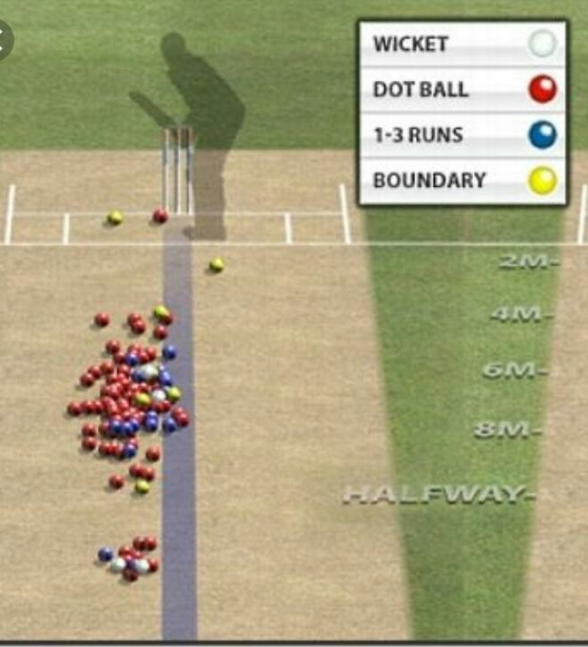

## Kohli always struggles against outswing from Right Arm Fast bowlers.

### When ball pitches on good length and near outside off stump line. Many times he nicked it to the wicket keeper. c_wk (caught by wicket keeper) count is evidence of that.

```python
vkohli_dismissal_data[vkohli_dismissal_data.dismissal =='right-arm pace']
```

|  | dismissal | span | Dis | bwd | c_fie | c_wk | st | lbw | hw | ro | oth | no | ave | 0s | batsman | match_type |
| --- | --- | --- | --- | --- | --- | --- | --- | --- | --- | --- | --- | --- | --- | --- | --- | --- |
| 6 | right-arm pace | 2011-2020 | 30 | 2 | 20 | 6 | 0 | 2 | 0 | 0 | 0 | 0 | 27.56 | 1 | Virat Kohli | T20 |
| 36 | right-arm pace | 2011-2020 | 77 | 3 | 34 | 21 | 0 | 19 | 0 | 0 | 0 | 0 | 38.53 | 9 | Virat Kohli | Test |
| 69 | right-arm pace | 2008-2020 | 103 | 11 | 53 | 33 | 0 | 6 | 0 | 0 | 0 | 0 | 44.45 | 8 | Virat Kohli | ODI |

```python
data_ra_pacers = list_of_dismissal_combined[list_of_dismissal_combined.bowler_type == 'right_arm_pace']
```

```python
plt.figure(figsize=(12,5))
sns.countplot(x = "how out", hue = "match_type",data = data_ra_pacers)
plt.legend(prop={'size':10})
plt.title("Virat Kohli's dismissal by Right Arm Pacers",fontsize=30)
plt.xlabel("Dismissal_kind",fontsize=30)
plt.ylabel("Dismissal count",fontsize=30)
```

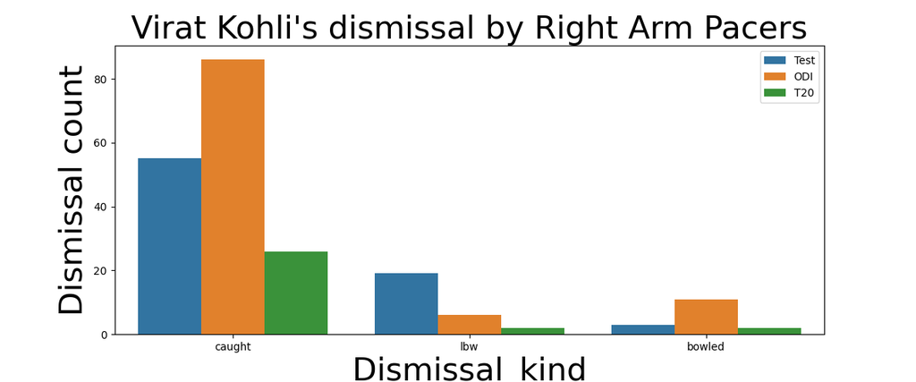

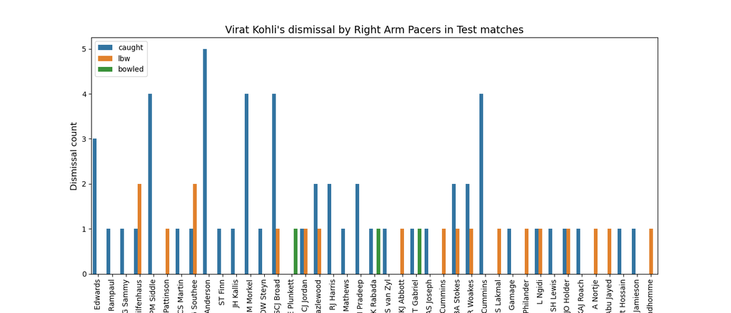

```python
plt.figure(figsize=(14,6))
sns.countplot(x = "bowler", hue = "how out",data = data_ra_pacers[data_ra_pacers.match_type == "Test"])
plt.legend(prop={'size':10})
plt.title("Virat Kohli's dismissal by Right Arm Pacers in Test matches",fontsize=14)
plt.xlabel("Bowlers",fontsize=12)
plt.ylabel("Dismissal count",fontsize=12)
plt.xticks(rotation=90)
plt.show()

plt.figure(figsize=(14,6))
sns.countplot(x = "bowler", hue = "how out",data = data_ra_pacers[data_ra_pacers.match_type == "T20"])
plt.legend(prop={'size':10})
plt.title("Virat Kohli's dismissal by Right Arm Pacers in T20",fontsize=14)
plt.xlabel("Bowlers",fontsize=12)
plt.ylabel("Dismissal count",fontsize=12)
plt.xticks(rotation=90)
plt.show()

plt.figure(figsize=(14,6))
sns.countplot(x = "bowler", hue = "how out",data = data_ra_pacers[data_ra_pacers.match_type == "ODI"])
plt.legend(prop={'size':10})
plt.title("Virat Kohli's dismissal by Right Arm Pacers in ODI",fontsize=14)
plt.xlabel("Bowlers",fontsize=12)
plt.ylabel("Dismissal count",fontsize=12)
plt.xticks(rotation=90)
plt.show()
```

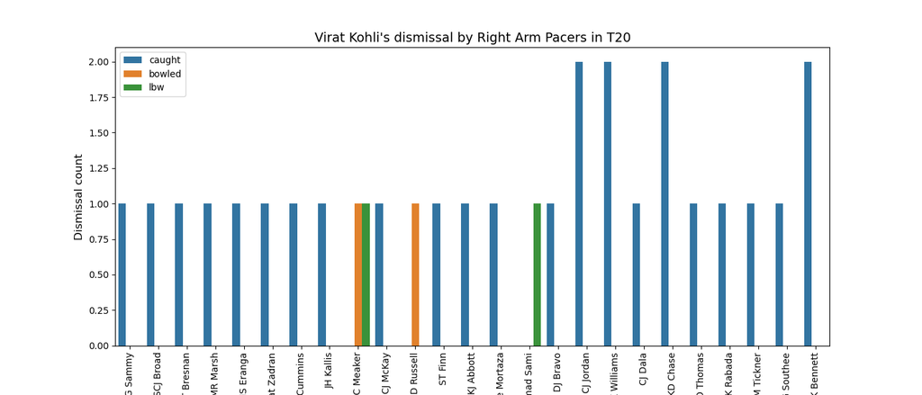

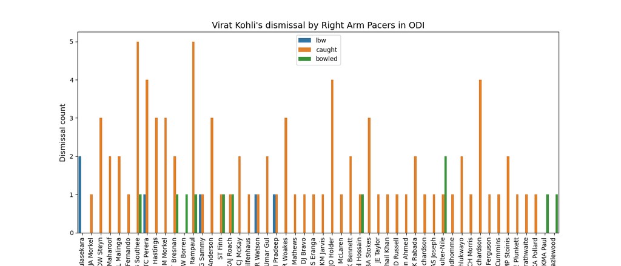

## Against the bowlers like James Anderson, Tim Southee Virat Kohli has got out caught behind or caught in slips so many times.

# 2) Left Arm Pace

### i] Virat Struggles against the left arm fast bowlers IN OR OUT swingers. ii] He has a very strong flick shot but against the IN SWINGER sometimes he went too much across the line and missed the ball hence, got out BOWLED, LBW or CAUGHT BEHIND. iii] Against the OUT SWINGING DELIVERY, from left arm pace bowler will take the leading edge and and Kohli has got out in similar fashion in so many matches. iv] Virat Kohli takes his front foot forward in his initial movement. This, combined with a strong bottom hand makes him predisposed to play the ball on to the leg side, across the pads. Consequently, He is a candidate for leg before wicket when he misses the ball.

### bwd = bowled , c_wk = Caught by wicket keeper, lbw -> proves above point

```python
vkohli_dismissal_data[vkohli_dismissal_data.dismissal =='left-arm pace']
```

|  | dismissal | span | Dis | bwd | c_fie | c_wk | st | lbw | hw | ro | oth | no | ave | 0s | batsman | match_type |
| --- | --- | --- | --- | --- | --- | --- | --- | --- | --- | --- | --- | --- | --- | --- | --- | --- |
| 8 | left-arm pace | 2012-2019 | 7 | 1 | 5 | 1 | 0 | 0 | 0 | 0 | 0 | 0 | 36.42 | 1 | Virat Kohli | T20 |
| 38 | left-arm pace | 2014-2020 | 13 | 1 | 8 | 3 | 0 | 1 | 0 | 0 | 0 | 0 | 49.69 | 1 | Virat Kohli | Test |
| 71 | left-arm pace | 2008-2019 | 28 | 4 | 16 | 7 | 0 | 1 | 0 | 0 | 0 | 0 | 31.14 | 3 | Virat Kohli | ODI |

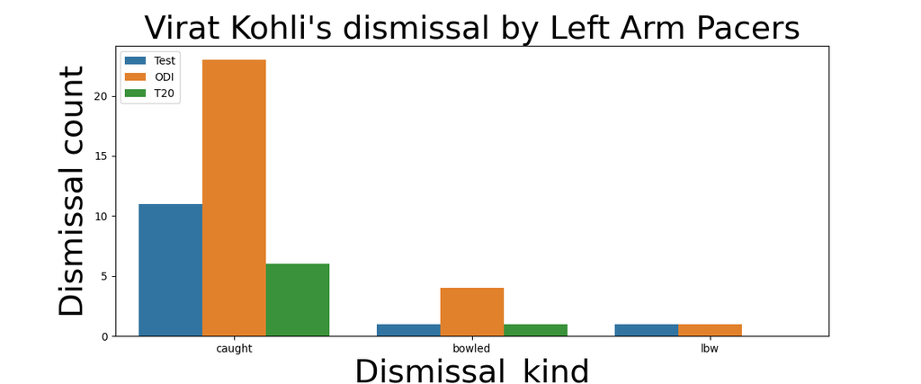

```python
data_la_pacers = list_of_dismissal_combined[list_of_dismissal_combined.bowler_type == 'left_arm_pace']
plt.figure(figsize=(12,5))
sns.countplot(x = "how out", hue = "match_type",data = data_la_pacers)
plt.legend(prop={'size':10})
plt.title("Virat Kohli's dismissal by Left Arm Pacers",fontsize=30)
plt.xlabel("Dismissal_kind",fontsize=30)
plt.ylabel("Dismissal count",fontsize=30)
plt.show()
```

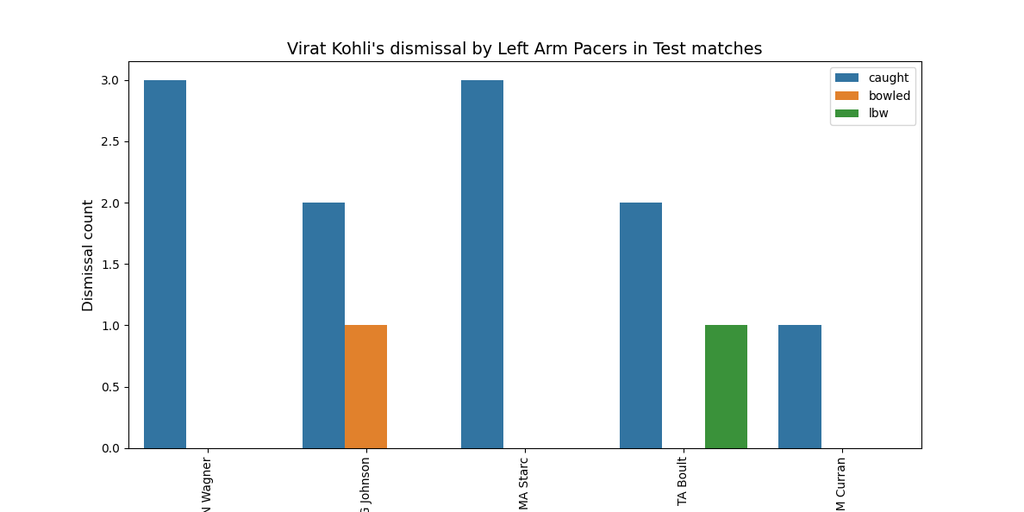

```python
plt.figure(figsize=(12,6))
sns.countplot(x = "bowler", hue = "how out",data = data_la_pacers[data_la_pacers.match_type == "Test"])
plt.legend(prop={'size':10})
plt.title("Virat Kohli's dismissal by Left Arm Pacers in Test matches",fontsize=14)
plt.xlabel("Bowlers",fontsize=12)
plt.ylabel("Dismissal count",fontsize=12)
plt.xticks(rotation=90)
plt.show()

plt.figure(figsize=(12,6))
sns.countplot(x = "bowler", hue = "how out",data = data_la_pacers[data_la_pacers.match_type == "T20"])
plt.legend(prop={'size':10})
plt.title("Virat Kohli's dismissal by Left Arm Pacers in T20",fontsize=14)
plt.xlabel("Bowlers",fontsize=12)
plt.ylabel("Dismissal count",fontsize=12)
plt.xticks(rotation=90)
plt.show()

plt.figure(figsize=(16,6))
sns.countplot(x = "bowler", hue = "how out",data = data_la_pacers[data_la_pacers.match_type == "ODI"])
plt.legend(prop={'size':10})
plt.title("Virat Kohli's dismissal by Left Arm Pacers in ODI",fontsize=14)
plt.xlabel("Bowlers",fontsize=12)
plt.ylabel("Dismissal count",fontsize=12)
plt.xticks(rotation=90)
plt.show()
```

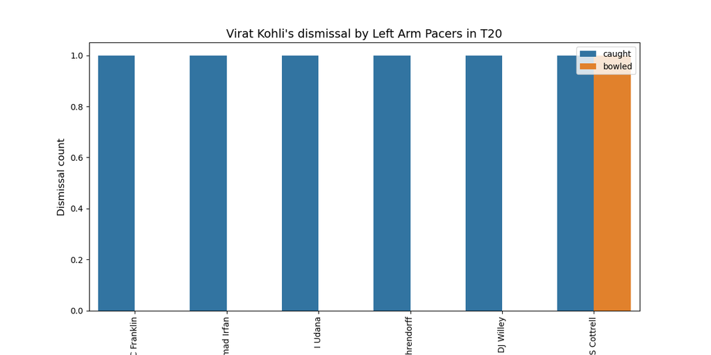

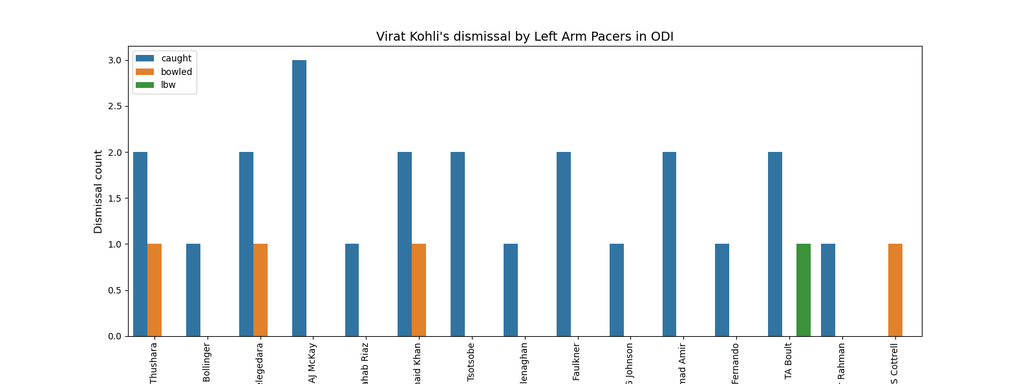

### In 2011 against Wahab Riaz In 2015 against Mitchell Johnson In 2017 Champions Trophy, final against Mohammad Amir In 2019 against T Boult

### In 2012-13 bilateral series gainst Pakistan he got out against Junaid Khan thrice in 3 ODIs.

# 3) Against Spinners

[figure not shown]

## Virat Struggles against spinners (Leg spinners) speciallly against the googly in shorter formats.

## He has a very strong Cover drive but sometimes he doesn't pick leg spinners googly and misses the line completely, due to this he got out BOWLED or LBW many a times.

### following table shows the number of times he got bowled and LBW against the spinners

```python
vkohli_dismissal_data[(vkohli_dismissal_data.dismissal =='left-arm spin') |
                     (vkohli_dismissal_data.dismissal =='right-arm spin')]
```

|  | dismissal | span | Dis | bwd | c_fie | c_wk | st | lbw | hw | ro | oth | no | ave | 0s | batsman | match_type |
| --- | --- | --- | --- | --- | --- | --- | --- | --- | --- | --- | --- | --- | --- | --- | --- | --- |
| 7 | right-arm spin | 2011-2019 | 10 | 3 | 6 | 1 | 0 | 0 | 0 | 0 | 0 | 0 | 25.80 | 0 | Virat Kohli | T20 |
| 9 | left-arm spin | 2012-2018 | 3 | 0 | 1 | 1 | 0 | 1 | 0 | 0 | 0 | 0 | 37.66 | 0 | Virat Kohli | T20 |
| 37 | right-arm spin | 2011-2019 | 35 | 2 | 21 | 3 | 0 | 8 | 1 | 0 | 0 | 0 | 61.45 | 0 | Virat Kohli | Test |
| 39 | left-arm spin | 2012-2019 | 9 | 1 | 6 | 0 | 0 | 2 | 0 | 0 | 0 | 0 | 74.44 | 0 | Virat Kohli | Test |
| 70 | right-arm spin | 2009-2020 | 44 | 9 | 21 | 4 | 3 | 6 | 1 | 0 | 0 | 0 | 52.13 | 0 | Virat Kohli | ODI |
| 72 | left-arm spin | 2009-2017 | 13 | 3 | 7 | 1 | 1 | 1 | 0 | 0 | 0 | 0 | 32.61 | 0 | Virat Kohli | ODI |

```python
data_spinners = list_of_dismissal_combined[(list_of_dismissal_combined.bowler_type == 'left_arm_spin')|
                                           (list_of_dismissal_combined.bowler_type == 'right_arm_spin')]
```

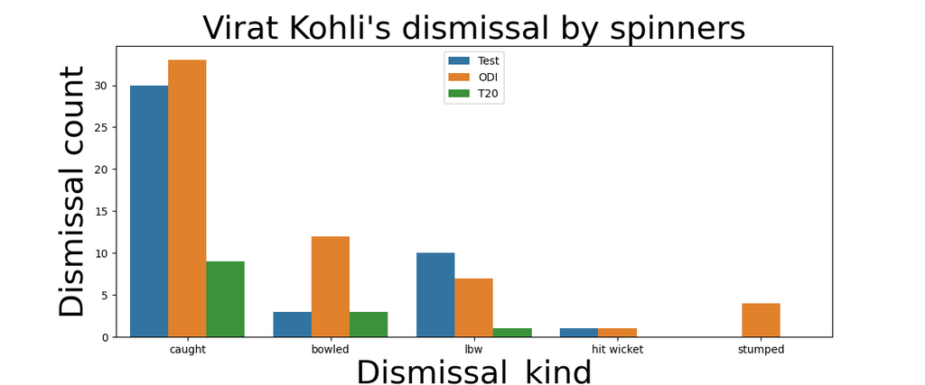

```python
plt.figure(figsize=(12,5))
sns.countplot(x = "how out", hue = "match_type",data = data_spinners)
plt.legend(prop={'size':10})
plt.title("Virat Kohli's dismissal by spinners",fontsize=30)
plt.xlabel("Dismissal_kind",fontsize=30)
plt.ylabel("Dismissal count",fontsize=30)
plt.show()
```

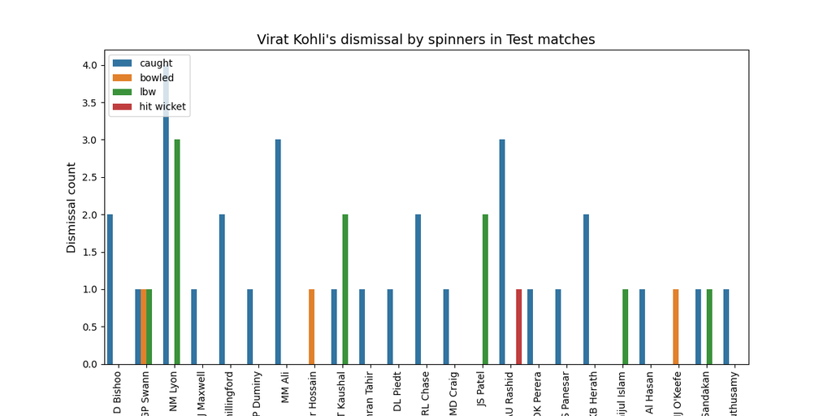

```python
plt.figure(figsize=(12,6))
sns.countplot(x = "bowler", hue = "how out",data = data_spinners[data_spinners.match_type == "Test"])
plt.legend(prop={'size':10})
plt.title("Virat Kohli's dismissal by spinners in Test matches",fontsize=14)
plt.xlabel("Bowlers",fontsize=12)
plt.ylabel("Dismissal count",fontsize=12)
plt.xticks(rotation=90)
plt.show()

plt.figure(figsize=(12,6))
sns.countplot(x = "bowler", hue = "how out",data = data_spinners[data_spinners.match_type == "T20"])
plt.legend(prop={'size':10})
plt.title("Virat Kohli's dismissal by spinners in T20",fontsize=14)
plt.xlabel("Bowlers",fontsize=12)
plt.ylabel("Dismissal count",fontsize=12)
plt.xticks(rotation=90)
plt.show()

plt.figure(figsize=(16,6))
sns.countplot(x = "bowler", hue = "how out",data = data_spinners[data_spinners.match_type == "ODI"])
plt.legend(prop={'size':10})
plt.title("Virat Kohli's dismissal by spinners in ODI",fontsize=14)
plt.xlabel("Bowlers",fontsize=12)
plt.ylabel("Dismissal count",fontsize=12)
plt.xticks(rotation=90)
plt.show()
```

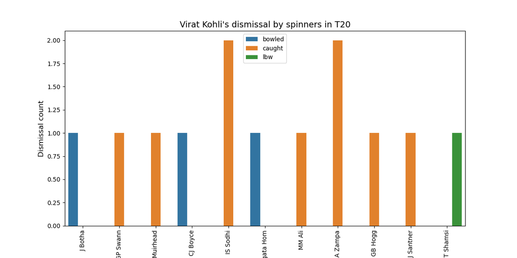

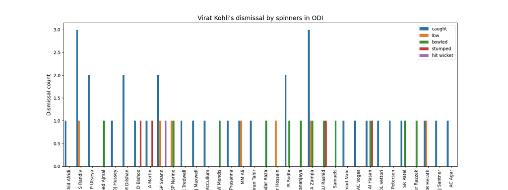

# To Conclude, Both Leg spinners and Pacers are challenges infront of him.

### He struggles on off stump line with ball swinging away from him.

### Against the left arm fast bowlers he always tries to play ON side. With ball swinging you will always have a chance against him

### With leggies try to bowl away from off stump, he always tries to play hard cover drive if you bowl googlies every now and then he'll struggle.

### Bowling near off stump with ball swinging... Virat Struggles